# Visualizing Search Strategies: Maze

**Notes:**

- Breaking ties:
  - The order in which the children are explored (see `available directions`) makes a big difference for DFS and dealing with empty spaces. I explore the directions in random order which makes the algorithm stochastic!
  - Ties for $h(n)$ and $f(n)$ need to be broken in a consistent manner. I use the most recently added node. To try to keep moving into the same direction.
- Cycles: Cycles are avoided using the reached data structure. For DFS, we can use the reached structure for checking or, without a reached structure implement cycle checking with only parent nodes.
- Depth-limited search needs ideas from best-first search to work with open spaces!

# Code

```
Helper functions for the Maze Assignment by M. Hahsler
Usage:
  import maze_helper as mh
  mh.show_some_mazes()

Here is an example maze:

XXXXXXXXXXXXXXXXXXXXXX
X XX        X X      X
X    XXXXXX X XXXXXX X
XXXXXX     S  X      X
X    X XXXXXX XX XXXXX
X XXXX X         X   X
X        XXX XXX   X X
XXXXXXXXXX    XXXXXX X
XG         XX        X
XXXXXXXXXXXXXXXXXXXXXX

The goal is at (np.int64(8), np.int64(1)).
```

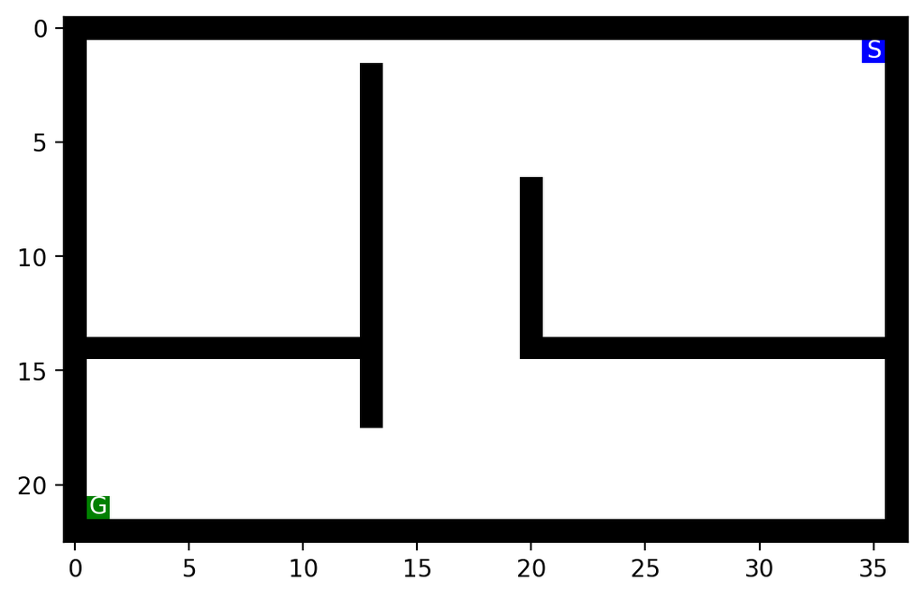

```python
%run maze_helper.py
%matplotlib inline
%config InlineBackend.figure_format = 'retina'

import numpy as np


#f = open("small_maze.txt", "r")
#f = open("medium_maze.txt", "r")
#f = open("large_maze.txt", "r")    # this has only one solution!
f = open("open_maze.txt", "r")
#f = open("empty_maze.txt", "r")
#f = open("empty_2_maze.txt", "r")
#f = open("wall_maze.txt", "r")
#f = open("loops_maze.txt", "r")
#f = open("L_maze.txt", "r")

maze_str = f.read()
maze = parse_maze(maze_str)

show_maze(maze)
```

The tree search code implementation is in tree_search.py (not published).

```python
# tree_search.py has my actual implementation
from tree_search_solution import *
import tree_search_solution as tree_search

# used heuristic
tree_search.heuristic = manhattan
#tree_search.heuristic = euclidean

# order in which we add new states to the frontier
tree_search.set_order("NESW")
#tree_search.set_order("WSEN")
#tree_search.set_order(random=True)
```

```
Directions are checked in the order ['N', 'E', 'S', 'W']
```

## Cycle checking option 1: Check in the path + check in the frontier

This unfortunately does not work and produces an infinite loop if there are any open spaces in the maze!

**Note:** It has to be manually stopped! I implement here max_tries to stop after a set number of expansions.

```python
 %time result = DFS(maze, animation = True, max_tries = 300, frontier_option = 2)

 animate_maze(result)
```

```
CPU times: user 21.1 ms, sys: 0 ns, total: 21.1 ms
Wall time: 20.2 ms
No solution found.
```

[video not shown]

Note that there are still frontier entires (orange squares) left when DFS removed a completed branch from memory (squares that turn white). This is a problem, since DFS will explore them again leading to an infinite loop.

## Cycle checking option 2: Check in the path + check in the frontier and move found nodes to the top

Increasing the priority od a frontier entry when we see it again solves this issue. Note that there are no orange squares left when DFS removes a path from memory so it knows that this part of the maze is done.

```python
%time result = DFS(maze, vis = False, animation = True, frontier_option = 1)

animate_maze(result)
```

```
CPU times: user 24.8 ms, sys: 1.02 ms, total: 25.9 ms
Wall time: 24.6 ms
Path length: 54
Reached squares: 0
Action sequence: ['W', 'W', 'W', 'W', 'W', 'W', 'W', 'W', 'W', 'W', 'W', 'W', 'W', 'W', 'W', 'W', 'W', 'W', 'W', 'W', 'W', 'S', 'S', 'S', 'S', 'S', 'S', 'S', 'S', 'S', 'S', 'S', 'S', 'S', 'S', 'S', 'S', 'S', 'W', 'W', 'W', 'W', 'W', 'W', 'W', 'W', 'W', 'W', 'W', 'W', 'W', 'S', 'S', 'S']
```

[video not shown]